# Health and Economic Impacts of U.S. Storms

treepruner

November 15, 2015

### Synopsis

This project involves exploring the U.S. National Oceanic and Atmospheric Administration’s (NOAA) storm database. This database tracks characteristics of major storms and weather events in the United States, including when and where they occur, as well as estimates of any fatalities, injuries, and property damage. The file contains data from 1950 - 2011.

The United States population health is impacted by weather events in terms of both fatalities and injuries.

More injuries are incurred as a result of tornados more than any other event group.

The greatest economic consequences are more difficult to determine due to the inconsistency of the cost unit coding. If ambiguous units are assumed to be in millions, extremes of water- drought and flooding, with drought being more than twice as expensive as flooding in the crop damage rankings.

For property damages, hurricanes, flooding and coastal flooding are the most expensive event groups.

### Data Processing

#### Load Data

```r
library(RCurl)
library(lubridate)
library(dplyr)
library(sqldf)
library(xtable)
library(ggplot2)
library(scales)
```

```r
if (!file.exists("./proj2/repdata%2Fdata%2FStormData.csv.bz2")) {
fileURL <- "https://d396qusza40orc.cloudfront.net/repdata%2Fdata%2FStormData.csv.bz2"
setInternet2(use = TRUE)
download.file(fileURL, "./proj2/repdata%2Fdata%2FStormData.csv.bz2", method = "curl")}

sd <- read.csv("./proj2/repdata%2Fdata%2FStormData.csv.bz2")

# save original
saveRDS(sd, "./proj2/stormData.rds")
```

#### Explore Data

```r
str(sd)
```

```
## 'data.frame':    902297 obs. of  37 variables:
##  $ STATE__   : num  1 1 1 1 1 1 1 1 1 1 ...
##  $ BGN_DATE  : Factor w/ 16335 levels "1/1/1966 0:00:00",..: 6523 6523 4242 11116 2224 2224 2260 383 3980 3980 ...
##  $ BGN_TIME  : Factor w/ 3608 levels "00:00:00 AM",..: 272 287 2705 1683 2584 3186 242 1683 3186 3186 ...
##  $ TIME_ZONE : Factor w/ 22 levels "ADT","AKS","AST",..: 7 7 7 7 7 7 7 7 7 7 ...
##  $ COUNTY    : num  97 3 57 89 43 77 9 123 125 57 ...
##  $ COUNTYNAME: Factor w/ 29601 levels "","5NM E OF MACKINAC BRIDGE TO PRESQUE ISLE LT MI",..: 13513 1873 4598 10592 4372 10094 1973 23873 24418 4598 ...
##  $ STATE     : Factor w/ 72 levels "AK","AL","AM",..: 2 2 2 2 2 2 2 2 2 2 ...
##  $ EVTYPE    : Factor w/ 985 levels "   HIGH SURF ADVISORY",..: 834 834 834 834 834 834 834 834 834 834 ...
##  $ BGN_RANGE : num  0 0 0 0 0 0 0 0 0 0 ...
##  $ BGN_AZI   : Factor w/ 35 levels "","  N"," NW",..: 1 1 1 1 1 1 1 1 1 1 ...
##  $ BGN_LOCATI: Factor w/ 54429 levels "","- 1 N Albion",..: 1 1 1 1 1 1 1 1 1 1 ...
##  $ END_DATE  : Factor w/ 6663 levels "","1/1/1993 0:00:00",..: 1 1 1 1 1 1 1 1 1 1 ...
##  $ END_TIME  : Factor w/ 3647 levels ""," 0900CST",..: 1 1 1 1 1 1 1 1 1 1 ...
##  $ COUNTY_END: num  0 0 0 0 0 0 0 0 0 0 ...
```

[output cut: 23 more lines]

```r
head(sd, 1)
```

```
##   STATE__          BGN_DATE BGN_TIME TIME_ZONE COUNTY COUNTYNAME STATE
## 1       1 4/18/1950 0:00:00     0130       CST     97     MOBILE    AL
##    EVTYPE BGN_RANGE BGN_AZI BGN_LOCATI END_DATE END_TIME COUNTY_END
## 1 TORNADO         0                                               0
##   COUNTYENDN END_RANGE END_AZI END_LOCATI LENGTH WIDTH F MAG FATALITIES
## 1         NA         0                        14   100 3   0          0
##   INJURIES PROPDMG PROPDMGEXP CROPDMG CROPDMGEXP WFO STATEOFFIC ZONENAMES
## 1       15      25          K       0
##   LATITUDE LONGITUDE LATITUDE_E LONGITUDE_ REMARKS REFNUM
## 1     3040      8812       3051       8806              1
```

#### Clean/Preprocess Data

##### Dates

lubridate was used to convert the dates that are factors into date fields so that date parts such as year could be used in the figures.

```r
sd$BGN_DATE <- mdy_hms(sd$BGN_DATE)
sd$END_DATE <- mdy_hms(sd$END_DATE)
```

##### EVTYPE Code Groupings

There are 985 unique EVTYPE codes, many of which are very similar. Rankings using this EVTYPE as it stands would be too disaggregated to be useful.

To make this reproducible by others, the entire mapping file has been read into this document in the appendix.

```r
envTypeMapping <- read.csv("./proj2/envTypeList.csv",  sep = ",")[, 2:3]

sd <- sqldf(
        "select s.*, e.envTypeGroup
         from sd s join envTypeMapping e on s.EVTYPE = e.ENVTYPE")
```

##### Duplicates

This section checks for duplicates and determines if the REFNUM identifies a unique row. Removed records that were exactly the same in all fields so that only 1 record out of the multiples remained in the file.

Others in the class discovered that there is another pair of records, REFNUM 605943 and 567221, that although they have different REFNUMs, appear to be for the same event. The REMARKS refer to millions in damage, so REFNUM 605943 which referred to billions in PROPDMGEXP, was removed.

```r
dup_refnum <- sqldf(
        "select s.REFNUM, count(*)
         from sd s
         group by s.REFNUM
         having count(*) > 1")

dup_refnum
```

```
##   REFNUM count(*)
## 1 233600        2
## 2 233653        2
```

```r
sd <- sqldf(
        "select distinct s.*
         from sd s"
         )

# this code also works and was actually faster
# sd1 <- sd[!duplicated(sd),]
```

##### Economic Damage Fields

The events in this file range from 1950 to 2011, however, the documentation states it was best documented from 1996 forward. In light of this, the analysis is just including the BGN_DATES from 1996 - 2011. I wasn’t able to get the date syntax correct with sqldf, so I’m doing that part with dplyr.

```r
sd0 <- sd %>% filter(year(BGN_DATE) >= 1996)

# save 1996-2011 data
saveRDS(sd0, "./proj2/sd0.rds")
```

The PROPDMG field is the numerical component of the property damage and the PROPDMGEXP is the units, however, the units field is dirty. The numerical field was multiplied as follows before dividing by 1,000,000 in order to present the amounts consistently in millions:

- Bb = 1,000,000,000
- Mm = 1,000,000,
- Kk = 1,000
- Hh = 100
- ? = 0
- anything else = 1,000,000

The CROPDMG field is the numerical component of the crop damage and the CROPDMGEXP is the units, however, the units field is also dirty. The numerical field was multiplied as follows before dividing by 1,000,000 in order to present the amounts consistently in millions:

- Bb = 1,000,000,000
- Mm = 1,000,000
- Kk = 1,000
- Hh = 100
- ? = 0
- anything else = 1,000,000

Another field was added to indicate the reliability of the numbers. Records containing “anything else” and “?” were coded as low reliability.

The REMARKS have cost numbers that do not always match the cost fields for that record. A future analysis should compare these fields and either adjust the reliability and/or update the damage numbers.

To truely be comparable and understandable to the modern audience, the damage dollar amounts should be adjusted using an appropriate price index into current dollars in order to properly rank the financial impact of each event. This was deemed out of scope for our assignment.

```r
sd1 <- sqldf(
        "select  REFNUM
        , BGN_DATE
        , END_DATE
        , EVTYPE
        , EnvTypeGroup
        , FATALITIES
        , INJURIES
        , PROPDMG
        , PROPDMGEXP
        , case
                when upper(PROPDMGEXP) = 'B' then round(PROPDMG * 1000000000,0)/1000000
                when upper(PROPDMGEXP) = 'M' then round(PROPDMG * 1000000,0)/1000000
                when upper(PROPDMGEXP) = 'K' then round(PROPDMG * 1000,0)/1000000
                when upper(PROPDMGEXP) = 'H' then round(PROPDMG * 100,0)/1000000
                when upper(PROPDMGEXP) = '?' then round(PROPDMG * 0,0)/1000000
           else round(PROPDMG * 1000000,0)/1000000
           end as PropertyDamageAmt
        , CROPDMG
        , CROPDMGEXP
        , case
                when upper(CROPDMGEXP) = 'B' then round(CROPDMG * 1000000000,0)/1000000
                when upper(CROPDMGEXP) = 'M' then round(CROPDMG * 1000000,0)/1000000
                when upper(CROPDMGEXP) = 'K' then round(CROPDMG * 1000,0)/1000000
                when upper(CROPDMGEXP) = 'H' then round(CROPDMG * 100,0)/1000000
                when upper(CROPDMGEXP) = '?' then round(CROPDMG * 0,0)/1000000
           else round(CROPDMG * 1000000,0)/1000000
           end as CropDamageAmt
        , case
                when upper(PROPDMGEXP) not in ('B', 'M', 'K', 'H') then 'Low'
                when upper(CROPDMGEXP) not in ('B', 'M', 'K', 'H') then 'Low'
          else 'High'
          end as reliability
        , REMARKS
         from sd0
         where REFNUM <> 605943 "          )

# save cleaned subset
saveRDS(sd1, "./proj2/sd1.rds")
```

### Results by Event Group

#### Population Health Statistics by Event Group

```r
pop_fatalities <-
        sd1 %>%
        group_by(EnvTypeGroup) %>%
        summarise(n = n()
                  , Fatalities.Count = sum(FATALITIES)
                  , Fatalities.Mean = mean(FATALITIES)
                  , Fatalities.Median = median(FATALITIES)
                  , Fatalities.Min = min(FATALITIES)
                  , Fatalities.Max = max(FATALITIES)        ) %>%
        arrange(desc(Fatalities.Count))
```

The fatalities from 1996 - 2011 are ranked as follows:

```r
fatalities <- xtable( pop_fatalities[pop_fatalities$Fatalities.Count != 0,], digits =  c(0,0,0,0,0,0,0,0) )
print(fatalities, type="html", include.rownames=FALSE)
```

| EnvTypeGroup | n | Fatalities.Count | Fatalities.Mean | Fatalities.Median | Fatalities.Min | Fatalities.Max |
| --- | --- | --- | --- | --- | --- | --- |
| Heat | 2760 | 2036 | 1 | 0 | 0 | 99 |
| Tornado/Waterspout | 32617 | 1513 | 0 | 0 | 0 | 158 |
| Flooding | 78796 | 1331 | 0 | 0 | 0 | 20 |
| Wind | 235508 | 763 | 0 | 0 | 0 | 8 |
| Lightning | 13203 | 650 | 0 | 0 | 0 | 4 |
| Rip Current | 734 | 542 | 1 | 1 | 0 | 6 |
| Wintery Mix | 37349 | 469 | 0 | 0 | 0 | 8 |
| Cold | 4083 | 398 | 0 | 0 | 0 | 14 |
| Avalanche | 378 | 223 | 1 | 0 | 0 | 6 |
| Coastal Flooding | 2351 | 170 | 0 | 0 | 0 | 11 |
| Hurricane | 273 | 125 | 0 | 0 | 0 | 15 |
| Rain | 11656 | 94 | 0 | 0 | 0 | 19 |
| Fire | 4199 | 87 | 0 | 0 | 0 | 14 |
| Blizzard | 2636 | 70 | 0 | 0 | 0 | 7 |
| Fog | 1728 | 69 | 0 | 0 | 0 | 11 |
| Tropical Storm | 682 | 57 | 0 | 0 | 0 | 22 |
| Landslide | 620 | 43 | 0 | 0 | 0 | 14 |
| Tsunami | 20 | 33 | 2 | 0 | 0 | 32 |
| Thunderstorm | 12183 | 22 | 0 | 0 | 0 | 5 |
| Heavy Seas | 15 | 14 | 1 | 0 | 0 | 4 |
| Dust Storm | 557 | 13 | 0 | 0 | 0 | 3 |
| Hail | 208217 | 7 | 0 | 0 | 0 | 1 |
| Drowning | 1 | 1 | 1 | 1 | 1 | 1 |
| Marine Mishap | 1 | 1 | 1 | 1 | 1 | 1 |

```r
pop_fatalities_yr <-
        sd1 %>%
        mutate(Year = year(BGN_DATE)) %>%
        group_by(Year, EnvTypeGroup) %>%
        summarise(n = n()
                  , Fatalities.Count = sum(FATALITIES) ) %>%
        arrange(Year) %>%
        filter(EnvTypeGroup %in% c("Tornado/Waterspout", "Heat", "Flooding" ))
```

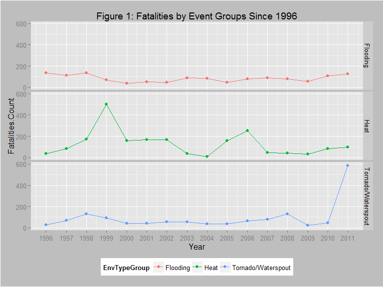

Figure 1: Fatalities

```r
ggplot( data = pop_fatalities_yr
        , aes(x = Year
        , y = Fatalities.Count , colour = EnvTypeGroup)) +
        geom_point() +
        scale_x_continuous(breaks=seq(1996, 2011, 1)) +
        facet_grid(EnvTypeGroup ~ .) +
        geom_line()  +
        theme(legend.position = "bottom", plot.background = element_rect(fill = "grey")) +
        ggtitle("Figure 1: Fatalities by Event Groups Since 1996")
```

```r
pop_injuries <-
        sd1 %>%
        group_by(EnvTypeGroup) %>%
        summarise(n = n()
                  , Injuries.Count = sum(INJURIES)
                  , Injuries.Mean = mean(INJURIES)
                  , Injuries.Median = median(INJURIES)
                  , Injuries.Min = min(INJURIES)
                  , Injuries.Max = max(INJURIES)    ) %>%
        arrange(desc(Injuries.Count))
```

The injuries from 1996 - 2011 are ranked as follows:

```r
injuries <- xtable(pop_injuries[pop_injuries$Injuries.Count != 0,], digits = c(0,0,0,0,0,0,0,0) )
print(injuries, type="html", include.rownames=FALSE)
```

| EnvTypeGroup | n | Injuries.Count | Injuries.Mean | Injuries.Median | Injuries.Min | Injuries.Max |
| --- | --- | --- | --- | --- | --- | --- |
| Tornado/Waterspout | 32617 | 20670 | 1 | 0 | 0 | 1150 |
| Flooding | 78796 | 8512 | 0 | 0 | 0 | 800 |
| Heat | 2760 | 7702 | 3 | 0 | 0 | 519 |
| Wind | 235508 | 6638 | 0 | 0 | 0 | 70 |
| Lightning | 13203 | 4140 | 0 | 0 | 0 | 51 |
| Wintery Mix | 37349 | 3223 | 0 | 0 | 0 | 165 |
| Fire | 4199 | 1458 | 0 | 0 | 0 | 90 |
| Hurricane | 273 | 1328 | 5 | 0 | 0 | 780 |
| Fog | 1728 | 855 | 0 | 0 | 0 | 78 |
| Hail | 208217 | 723 | 0 | 0 | 0 | 88 |
| Rip Current | 734 | 503 | 1 | 0 | 0 | 35 |
| Dust Storm | 557 | 415 | 1 | 0 | 0 | 40 |
| Blizzard | 2636 | 385 | 0 | 0 | 0 | 150 |
| Tropical Storm | 682 | 338 | 0 | 0 | 0 | 200 |
| Coastal Flooding | 2351 | 298 | 0 | 0 | 0 | 55 |
| Rain | 11656 | 234 | 0 | 0 | 0 | 32 |
| Avalanche | 378 | 156 | 0 | 0 | 0 | 7 |
| Cold | 4083 | 135 | 0 | 0 | 0 | 29 |
| Tsunami | 20 | 129 | 6 | 0 | 0 | 129 |
| Thunderstorm | 12183 | 59 | 0 | 0 | 0 | 13 |
| Landslide | 620 | 55 | 0 | 0 | 0 | 10 |
| Heavy Seas | 15 | 8 | 1 | 0 | 0 | 5 |
| Drought | 2514 | 4 | 0 | 0 | 0 | 4 |
| Unknown | 126 | 4 | 0 | 0 | 0 | 4 |
| Marine Mishap | 1 | 2 | 2 | 2 | 2 | 2 |

```r
pop_injuries_yr <-
        sd1 %>%
        mutate(Year = year(BGN_DATE)) %>%
        group_by(Year, EnvTypeGroup) %>%
        summarise(n = n()
                  , Injuries.Count = sum(INJURIES) ) %>%
        arrange(Year) %>%
        filter(EnvTypeGroup %in% c("Tornado/Waterspout", "Heat", "Flooding", "Wind", "Wintery Mix", "Lightning", "Lighting" ))
```

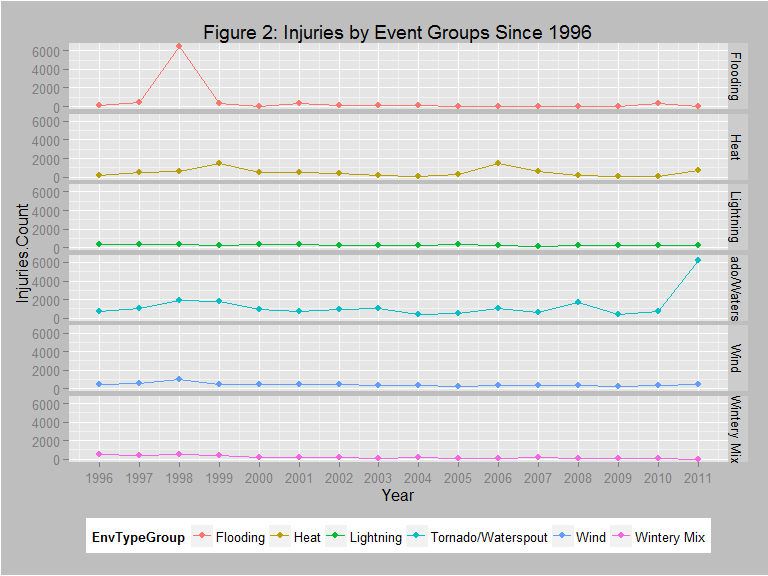

Figure 2: Injuries

```r
ggplot( data = pop_injuries_yr
        , aes(x = Year
        , y = Injuries.Count, colour = EnvTypeGroup)) +
        geom_point() +
        scale_x_continuous(breaks=seq(1996, 2011, 1)) +
        facet_grid(EnvTypeGroup ~ .) +
        geom_line() +
        theme(legend.position = "bottom", plot.background = element_rect(fill = "grey")) +
        ggtitle("Figure 2: Injuries by Event Groups Since 1996")
```

#### Economic Impact Statistics (displayed in millions)

```r
cost_PropertyDamage <-
        sd1 %>%
        group_by(EnvTypeGroup) %>%
        summarise(n = n()
                  , PropertyDamageAmt.Sum = sum(PropertyDamageAmt)
                  , PropertyDamageAmt.Mean = mean(PropertyDamageAmt)
                  , PropertyDamageAmt.Median = median(PropertyDamageAmt)
                  , PropertyDamageAmt.Min_ = min(PropertyDamageAmt)
                  , PropertyDamageAmt.Max = max(PropertyDamageAmt)   ) %>%
        arrange(desc(PropertyDamageAmt.Sum))

cost_PropertyDamage_High <-
        sd1 %>%
        filter(reliability == "High")  %>%
        group_by(EnvTypeGroup) %>%
        summarise(n = n()
                  , PropertyDamageAmt.Sum = sum(PropertyDamageAmt)
                  , PropertyDamageAmt.Mean = mean(PropertyDamageAmt)
                  , PropertyDamageAmt.Median = median(PropertyDamageAmt)
                  , PropertyDamageAmt.Min_ = min(PropertyDamageAmt)
                  , PropertyDamageAmt.Max = max(PropertyDamageAmt)   ) %>%
        arrange(desc(PropertyDamageAmt.Sum))


cost_CropDamage <-
        sd1 %>%
        group_by(EnvTypeGroup) %>%
        summarise(n_date = n()
                  , CropDamageAmt.Sum = sum(CropDamageAmt)
                  , CropDamageAmt.Mean = mean(CropDamageAmt)
                  , CropDamageAmt.Median = median(CropDamageAmt)
                  , CropDamageAmt.Min = min(CropDamageAmt)
                  , CropDamageAmt.Max = max(CropDamageAmt)   ) %>%
        arrange(desc(CropDamageAmt.Sum))

cost_CropDamage_High <-
        sd1 %>%
        filter(reliability == "High")  %>%
        group_by(EnvTypeGroup) %>%
        summarise(n_date = n()
                  , CropDamageAmt.Sum = sum(CropDamageAmt)
                  , CropDamageAmt.Mean = mean(CropDamageAmt)
                  , CropDamageAmt.Median = median(CropDamageAmt)
                  , CropDamageAmt.Min = min(CropDamageAmt)
                  , CropDamageAmt.Max = max(CropDamageAmt)   ) %>%
        arrange(desc(CropDamageAmt.Sum))
```

Total property damages from 1996 - 2011 (assuming millions for ambiguous cost units) are as follows:

```r
PropertyDamage <- xtable(cost_PropertyDamage[cost_PropertyDamage$PropertyDamageAmt.Sum != 0,], digits = c(0,0,0,0,0,0,0,0) )
print(PropertyDamage, type="html", include.rownames=FALSE)
```

| EnvTypeGroup | n | PropertyDamageAmt.Sum | PropertyDamageAmt.Mean | PropertyDamageAmt.Median | PropertyDamageAmt.Min_ | PropertyDamageAmt.Max |
| --- | --- | --- | --- | --- | --- | --- |
| Hurricane | 273 | 81719 | 299 | 1 | 0 | 16930 |
| Coastal Flooding | 2351 | 48347 | 21 | 0 | 0 | 31300 |
| Flooding | 78796 | 44359 | 1 | 0 | 0 | 3000 |
| Tornado/Waterspout | 32617 | 24623 | 1 | 0 | 0 | 2800 |
| Hail | 208217 | 14595 | 0 | 0 | 0 | 1800 |
| Wind | 235508 | 13338 | 0 | 0 | 0 | 1300 |
| Fire | 4199 | 7761 | 2 | 0 | 0 | 1500 |
| Tropical Storm | 682 | 7642 | 11 | 0 | 0 | 5150 |
| Wintery Mix | 37349 | 5889 | 0 | 0 | 0 | 750 |
| Drought | 2514 | 1046 | 0 | 0 | 0 | 645 |
| Lightning | 13203 | 743 | 0 | 0 | 0 | 15 |
| Rain | 11656 | 599 | 0 | 0 | 0 | 70 |
| Blizzard | 2636 | 526 | 0 | 0 | 0 | 102 |
| Landslide | 620 | 327 | 1 | 0 | 0 | 56 |
| Tsunami | 20 | 144 | 7 | 0 | 0 | 81 |
| Cold | 4083 | 51 | 0 | 0 | 0 | 8 |
| Fog | 1728 | 20 | 0 | 0 | 0 | 2 |
| Thunderstorm | 12183 | 16 | 0 | 0 | 0 | 8 |
| Heat | 2760 | 9 | 0 | 0 | 0 | 3 |
| Dust Storm | 557 | 6 | 0 | 0 | 0 | 1 |
| Avalanche | 378 | 4 | 0 | 0 | 0 | 1 |
| Tropical Depression | 60 | 2 | 0 | 0 | 0 | 1 |
| Dam Failure | 4 | 1 | 0 | 0 | 0 | 1 |
| Seiche | 21 | 1 | 0 | 0 | 0 | 1 |
| Volcano | 30 | 0 | 0 | 0 | 0 | 0 |
| Low Tide | 174 | 0 | 0 | 0 | 0 | 0 |
| Rip Current | 734 | 0 | 0 | 0 | 0 | 0 |
| Unknown | 126 | 0 | 0 | 0 | 0 | 0 |
| Marine Mishap | 1 | 0 | 0 | 0 | 0 | 0 |
| Heavy Seas | 15 | 0 | 0 | 0 | 0 | 0 |

```r
PropertyDamageHigh <- xtable(cost_PropertyDamage_High[cost_PropertyDamage_High$PropertyDamageAmt.Sum != 0,], digits = c(0,0,0,0,0,0,0,0) )
print(PropertyDamageHigh, type="html", include.rownames=FALSE)
```

| EnvTypeGroup | n | PropertyDamageAmt.Sum | PropertyDamageAmt.Mean | PropertyDamageAmt.Median | PropertyDamageAmt.Min_ | PropertyDamageAmt.Max |
| --- | --- | --- | --- | --- | --- | --- |
| Hurricane | 105 | 36472 | 347 | 11 | 0 | 5880 |
| Flooding | 34976 | 24703 | 1 | 0 | 0 | 2000 |
| Tornado/Waterspout | 12608 | 16036 | 1 | 0 | 0 | 2800 |
| Hail | 79215 | 7602 | 0 | 0 | 0 | 1800 |
| Wind | 101314 | 6591 | 0 | 0 | 0 | 929 |
| Coastal Flooding | 1071 | 4894 | 5 | 0 | 0 | 4000 |
| Fire | 1818 | 3547 | 2 | 0 | 0 | 1040 |
| Wintery Mix | 21030 | 2082 | 0 | 0 | 0 | 750 |
| Tropical Storm | 412 | 1045 | 3 | 0 | 0 | 530 |
| Lightning | 4154 | 313 | 0 | 0 | 0 | 15 |
| Rain | 5253 | 274 | 0 | 0 | 0 | 70 |
| Drought | 1399 | 234 | 0 | 0 | 0 | 23 |
| Landslide | 320 | 150 | 0 | 0 | 0 | 48 |
| Tsunami | 19 | 144 | 8 | 0 | 0 | 81 |
| Blizzard | 1739 | 39 | 0 | 0 | 0 | 6 |
| Cold | 2351 | 22 | 0 | 0 | 0 | 5 |
| Dust Storm | 253 | 4 | 0 | 0 | 0 | 1 |
| Heat | 1334 | 3 | 0 | 0 | 0 | 2 |
| Fog | 921 | 3 | 0 | 0 | 0 | 1 |
| Avalanche | 154 | 2 | 0 | 0 | 0 | 1 |
| Tropical Depression | 27 | 1 | 0 | 0 | 0 | 1 |
| Thunderstorm | 5816 | 1 | 0 | 0 | 0 | 0 |
| Low Tide | 174 | 0 | 0 | 0 | 0 | 0 |
| Seiche | 7 | 0 | 0 | 0 | 0 | 0 |
| Rip Current | 277 | 0 | 0 | 0 | 0 | 0 |

Total crop damages from 1996 - 2011 (assuming millions for ambiguous cost units) are as follows:

```r
CropDamage <- xtable(cost_CropDamage[cost_CropDamage$CropDamageAmt.Sum != 0,], digits = c(0,0,0,0,0,0,0,0) )
print(CropDamage, type="html", include.rownames=FALSE)
```

| EnvTypeGroup | n_date | CropDamageAmt.Sum | CropDamageAmt.Mean | CropDamageAmt.Median | CropDamageAmt.Min | CropDamageAmt.Max |
| --- | --- | --- | --- | --- | --- | --- |
| Drought | 2514 | 13368 | 5 | 0 | 0 | 1000 |
| Flooding | 78796 | 6316 | 0 | 0 | 0 | 500 |
| Hurricane | 273 | 5350 | 20 | 0 | 0 | 1510 |
| Cold | 4083 | 2726 | 1 | 0 | 0 | 596 |
| Hail | 208217 | 2497 | 0 | 0 | 0 | 70 |
| Wind | 235508 | 1716 | 0 | 0 | 0 | 175 |
| Rain | 11656 | 740 | 0 | 0 | 0 | 200 |
| Tropical Storm | 682 | 678 | 1 | 0 | 0 | 200 |
| Heat | 2760 | 493 | 0 | 0 | 0 | 492 |
| Fire | 4199 | 402 | 0 | 0 | 0 | 90 |
| Tornado/Waterspout | 32617 | 283 | 0 | 0 | 0 | 70 |
| Wintery Mix | 37349 | 114 | 0 | 0 | 0 | 65 |
| Landslide | 620 | 20 | 0 | 0 | 0 | 20 |
| Blizzard | 2636 | 7 | 0 | 0 | 0 | 7 |
| Lightning | 13203 | 7 | 0 | 0 | 0 | 3 |
| Dust Storm | 557 | 3 | 0 | 0 | 0 | 2 |
| Unknown | 126 | 1 | 0 | 0 | 0 | 0 |
| Coastal Flooding | 2351 | 1 | 0 | 0 | 0 | 1 |
| Thunderstorm | 12183 | 0 | 0 | 0 | 0 | 0 |
| Tsunami | 20 | 0 | 0 | 0 | 0 | 0 |

```r
CropDamageHigh <- xtable(cost_CropDamage_High[cost_CropDamage$CropDamageAmt.Sum != 0,], digits = c(0,0,0,0,0,0,0,0) )
print(CropDamageHigh, type="html", include.rownames=FALSE)
```

| EnvTypeGroup | n_date | CropDamageAmt.Sum | CropDamageAmt.Mean | CropDamageAmt.Median | CropDamageAmt.Min | CropDamageAmt.Max |
| --- | --- | --- | --- | --- | --- | --- |
| Flooding | 34976 | 6100 | 0 | 0 | 0 | 500 |
| Hurricane | 105 | 5297 | 50 | 2 | 0 | 1510 |
| Hail | 79215 | 1730 | 0 | 0 | 0 | 70 |
| Drought | 1399 | 1635 | 1 | 0 | 0 | 344 |
| Wind | 101314 | 1617 | 0 | 0 | 0 | 175 |
| Cold | 2351 | 935 | 0 | 0 | 0 | 286 |
| Heat | 1334 | 492 | 0 | 0 | 0 | 492 |
| Tropical Storm | 412 | 451 | 1 | 0 | 0 | 102 |
| Fire | 1818 | 285 | 0 | 0 | 0 | 80 |
| Tornado/Waterspout | 12608 | 278 | 0 | 0 | 0 | 70 |
| Wintery Mix | 21030 | 108 | 0 | 0 | 0 | 65 |
| Rain | 5253 | 61 | 0 | 0 | 0 | 20 |
| Landslide | 320 | 20 | 0 | 0 | 0 | 20 |
| Blizzard | 1739 | 7 | 0 | 0 | 0 | 7 |
| Lightning | 4154 | 5 | 0 | 0 | 0 | 3 |
| Dust Storm | 253 | 2 | 0 | 0 | 0 | 2 |
| Coastal Flooding | 1071 | 1 | 0 | 0 | 0 | 1 |
| Thunderstorm | 5816 | 0 | 0 | 0 | 0 | 0 |
| Tsunami | 19 | 0 | 0 | 0 | 0 | 0 |
| Avalanche | 154 | 0 | 0 | 0 | 0 | 0 |

### Conclusion

The United States population health is impacted by weather events in terms of both fatalities and injuries.

More injuries are incurred as a result of tornados more than any other event group.

The greatest economic consequences are more difficult to determine due to the inconsistency of the cost unit coding. If ambiguous units are assumed to be in millions, extremes of water- drought and flooding, with drought being more than twice as expensive as flooding in the crop damage rankings.

For property damages, hurricanes, flooding and coastal flooding are the most expensive event groups.

Local emergency management personal should allocate resources for early warning systems to allow people to seek shelter before tornados, hurricanes and high wind events to reduce the possibility of injury and death from these events. .

### Appendix

Additional information can be found at these websites:

https://d396qusza40orc.cloudfront.net/repdata%2Fpeer2_doc%2Fpd01016005curr.pdf

https://d396qusza40orc.cloudfront.net/repdata%2Fpeer2_doc%2FNCDC%20Storm%20Events-FAQ%20Page.pdf

#### EVTYPE Grouping Table

The mapping table needs to be extracted from the HTML/PDF and created locally to reproduce this analysis.

```r
print(xtable(envTypeMapping) ,  type="html" , include.rownames=FALSE)
```

ENVTYPE

EnvTypeGroup

AVALANCE

Avalanche

AVALANCHE

Avalanche

HEAVY SNOW/BLIZZARD/AVALANCHE

Avalanche

BLIZZARD

Blizzard

BLIZZARD AND EXTREME WIND CHIL

Blizzard

BLIZZARD AND HEAVY SNOW

Blizzard

Blizzard Summary

Blizzard

BLIZZARD WEATHER

Blizzard

BLIZZARD/FREEZING RAIN

Blizzard

BLIZZARD/HEAVY SNOW

Blizzard

BLIZZARD/HIGH WIND

Blizzard

BLIZZARD/WINTER STORM

Blizzard

BLOWING DUST

Blizzard

BLOWING SNOW

Blizzard

GROUND BLIZZARD

Blizzard

HIGH WIND/ BLIZZARD

Blizzard

HIGH WIND/BLIZZARD

Blizzard

HIGH WIND/BLIZZARD/FREEZING RA

Blizzard

[output not shown]

COASTAL FLOOD

Coastal Flooding

ASTRONOMICAL HIGH TIDE

Coastal Flooding

BEACH EROSIN

Coastal Flooding

Beach Erosion

Coastal Flooding

BEACH EROSION

Coastal Flooding

BEACH EROSION/COASTAL FLOOD

Coastal Flooding

BEACH FLOOD

Coastal Flooding

BLOW-OUT TIDE

Coastal Flooding

BLOW-OUT TIDES

Coastal Flooding

COASTAL FLOODING/EROSION

Coastal Flooding

COASTAL EROSION

Coastal Flooding

COASTAL FLOOD

Coastal Flooding

Coastal Flood

Coastal Flooding

COASTAL FLOODING

Coastal Flooding

Coastal Flooding

Coastal Flooding

coastal flooding

Coastal Flooding

COASTAL FLOODING/EROSION

Coastal Flooding

COASTAL STORM

Coastal Flooding

Coastal Storm

Coastal Flooding

COASTAL SURGE

Coastal Flooding

COASTAL/TIDAL FLOOD

Coastal Flooding

COASTALFLOOD

Coastal Flooding

COASTALSTORM

Coastal Flooding

CSTL FLOODING/EROSION

Coastal Flooding

Erosion/Cstl Flood

Coastal Flooding

HAZARDOUS SURF

Coastal Flooding

HEAVY SURF

Coastal Flooding

Heavy Surf

Coastal Flooding

Heavy surf and wind

Coastal Flooding

HEAVY SURF COASTAL FLOODING

Coastal Flooding

HEAVY SURF/HIGH SURF

Coastal Flooding

HEAVY SWELLS

Coastal Flooding

HIGH SEAS

Coastal Flooding

HIGH SURF

Coastal Flooding

High Surf

Coastal Flooding

HIGH SURF ADVISORIES

Coastal Flooding

HIGH SURF ADVISORY

Coastal Flooding

HIGH TIDES

Coastal Flooding

HIGH WATER

Coastal Flooding

HIGH WIND AND HIGH TIDES

Coastal Flooding

HIGH WIND/SEAS

Coastal Flooding

HIGH WINDS/COASTAL FLOOD

Coastal Flooding

STORM SURGE

Coastal Flooding

STORM SURGE/TIDE

Coastal Flooding

TIDAL FLOOD

Coastal Flooding

Tidal Flooding

Coastal Flooding

TIDAL FLOODING

Coastal Flooding

AGRICULTURAL FREEZE

Cold

BITTER WIND CHILL

Cold

BITTER WIND CHILL TEMPERATURES

Cold

COLD

Cold

Cold

Cold

Cold and Frost

Cold

COLD AND FROST

Cold

COLD AND SNOW

Cold

COLD AND WET CONDITIONS

Cold

Cold Temperature

Cold

COLD TEMPERATURES

Cold

COLD WAVE

Cold

COLD WEATHER

Cold

COLD WIND CHILL TEMPERATURES

Cold

COLD/WIND CHILL

Cold

COLD/WINDS

Cold

COOL AND WET

Cold

COOL SPELL

Cold

DAMAGING FREEZE

Cold

Damaging Freeze

Cold

EARLY FREEZE

Cold

EARLY FROST

Cold

Early Frost

Cold

Excessive Cold

Cold

Extended Cold

Cold

EXTREME COLD

Cold

Extreme Cold

Cold

EXTREME COLD/WIND CHILL

Cold

EXTREME WIND CHILL

Cold

EXTREME WIND CHILL/BLOWING SNO

Cold

EXTREME WIND CHILLS

Cold

EXTREME WINDCHILL

Cold

EXTREME WINDCHILL TEMPERATURES

Cold

EXTREME/RECORD COLD

Cold

FIRST FROST

Cold

FOG AND COLD TEMPERATURES

Cold

FREEZE

Cold

Freeze

Cold

FROST

Cold

Frost

Cold

Frost/Freeze

Cold

FROST/FREEZE

Cold

FROST

Cold

HARD FREEZE

Cold

HIGH WIND/LOW WIND CHILL

Cold

HIGH WIND/WIND CHILL

Cold

HIGH WIND/WIND CHILL/BLIZZARD

Cold

HIGH WINDS AND WIND CHILL

Cold

HYPERTHERMIA/EXPOSURE

Cold

HYPOTHERMIA

Cold

Hypothermia/Exposure

Cold

HYPOTHERMIA/EXPOSURE

Cold

LATE FREEZE

Cold

LOW TEMPERATURE

Cold

LOW TEMPERATURE RECORD

Cold

LOW WIND CHILL

Cold

PROLONG COLD

Cold

Prolong Cold

Cold

PROLONG COLD/SNOW

Cold

RECORD COLD

Cold

RECORD COLD

Cold

Record Cold

Cold

RECORD COLD AND HIGH WIND

Cold

RECORD COLD/FROST

Cold

RECORD COOL

Cold

RECORD LOW

Cold

SEVERE COLD

Cold

Temperature record

Cold

Unseasonable Cold

Cold

UNSEASONABLY COLD

Cold

UNSEASONABLY COOL

Cold

UNSEASONABLY COOL & WET

Cold

UNSEASONAL LOW TEMP

Cold

UNUSUALLY COLD

Cold

WIND CHILL

Cold

WIND CHILL/HIGH WIND

Cold

DAM BREAK

Dam Failure

DAM FAILURE

Dam Failure

ABNORMALLY DRY

Drought

BELOW NORMAL PRECIPITATION

Drought

DRIEST MONTH

Drought

DROUGHT

Drought

DROUGHT/EXCESSIVE HEAT

Drought

DRY

Drought

DRY CONDITIONS

Drought

DRY PATTERN

Drought

DRY SPELL

Drought

DRY WEATHER

Drought

DRYNESS

Drought

EXCESSIVE HEAT/DROUGHT

Drought

EXCESSIVELY DRY

Drought

HEAT DROUGHT

Drought

HEAT WAVE DROUGHT

Drought

Record dry month

Drought

RECORD DRYNESS

Drought

RECORD LOW RAINFALL

Drought

UNSEASONABLY DRY

Drought

VERY DRY

Drought

WARM DRY CONDITIONS

Drought

DROWNING

Drowning

DUST DEVEL

Dust Storm

DUST DEVIL

Dust Storm

Dust Devil

Dust Storm

DUST DEVIL WATERSPOUT

Dust Storm

DUST STORM

Dust Storm

DUST STORM/HIGH WINDS

Dust Storm

DUSTSTORM

Dust Storm

HIGH WINDS DUST STORM

Dust Storm

SAHARAN DUST

Dust Storm

Saharan Dust

Dust Storm

BRUSH FIRE

Fire

BRUSH FIRES

Fire

DENSE SMOKE

Fire

FOREST FIRES

Fire

GRASS FIRES

Fire

RED FLAG FIRE WX

Fire

SMOKE

Fire

WILD FIRES

Fire

WILD/FOREST FIRE

Fire

WILD/FOREST FIRES

Fire

WILDFIRE

Fire

WILDFIRES

Fire

FLASH FLOOD

Flooding

BREAKUP FLOODING

Flooding

FLASH FLOOD

Flooding

FLASH FLOOD - HEAVY RAIN

Flooding

FLASH FLOOD FROM ICE JAMS

Flooding

FLASH FLOOD WINDS

Flooding

FLASH FLOOD/

Flooding

FLASH FLOOD/ FLOOD

Flooding

FLASH FLOOD/ STREET

Flooding

FLASH FLOOD/FLOOD

Flooding

FLASH FLOOD/HEAVY RAIN

Flooding

FLASH FLOODING

Flooding

FLASH FLOODING/FLOOD

Flooding

FLASH FLOODING/THUNDERSTORM WI

Flooding

FLASH FLOODS

Flooding

FLASH FLOOODING

Flooding

FLOOD

Flooding

Flood

Flooding

FLOOD & HEAVY RAIN

Flooding

FLOOD FLASH

Flooding

FLOOD FLOOD/FLASH

Flooding

FLOOD WATCH/

Flooding

FLOOD/FLASH

Flooding

FLOOD/FLASH FLOOD

Flooding

Flood/Flash Flood

Flooding

FLOOD/FLASH FLOODING

Flooding

FLOOD/FLASH/FLOOD

Flooding

FLOOD/FLASHFLOOD

Flooding

FLOOD/RAIN/WIND

Flooding

FLOOD/RAIN/WINDS

Flooding

FLOOD/RIVER FLOOD

Flooding

Flood/Strong Wind

Flooding

FLOODING

Flooding

FLOODING/HEAVY RAIN

Flooding

FLOODS

Flooding

HIGH WINDS/FLOODING

Flooding

HIGHWAY FLOODING

Flooding

LAKE FLOOD

Flooding

LAKESHORE FLOOD

Flooding

LOCAL FLASH FLOOD

Flooding

LOCAL FLOOD

Flooding

MAJOR FLOOD

Flooding

MINOR FLOOD

Flooding

MINOR FLOODING

Flooding

Minor Flooding

Flooding

RAPIDLY RISING WATER

Flooding

RIVER AND STREAM FLOOD

Flooding

RIVER FLOOD

Flooding

RIVER FLOODING

Flooding

River Flooding

Flooding

RURAL FLOOD

Flooding

SMALL STREAM

Flooding

SMALL STREAM AND

Flooding

SMALL STREAM AND URBAN FLOOD

Flooding

SMALL STREAM AND URBAN FLOODIN

Flooding

SMALL STREAM FLOOD

Flooding

SMALL STREAM FLOODING

Flooding

SMALL STREAM URBAN FLOOD

Flooding

SMALL STREAM/URBAN FLOOD

Flooding

Sml Stream Fld

Flooding

SNOWMELT FLOODING

Flooding

STREAM FLOODING

Flooding

STREET FLOOD

Flooding

STREET FLOODING

Flooding

URBAN AND SMALL

Flooding

URBAN AND SMALL STREAM

Flooding

URBAN AND SMALL STREAM FLOOD

Flooding

URBAN AND SMALL STREAM FLOODIN

Flooding

URBAN FLOOD

Flooding

Urban flood

Flooding

Urban Flood

Flooding

URBAN FLOOD LANDSLIDE

Flooding

URBAN FLOODING

Flooding

Urban Flooding

Flooding

URBAN FLOODS

Flooding

URBAN SMALL

Flooding

URBAN SMALL STREAM FLOOD

Flooding

URBAN/SMALL

Flooding

URBAN/SMALL FLOODING

Flooding

URBAN/SMALL STREAM

Flooding

URBAN/SMALL STREAM FLOOD

Flooding

URBAN/SMALL STREAM FLOOD

Flooding

URBAN/SMALL STREAM FLOODING

Flooding

URBAN/SMALL STRM FLDG

Flooding

URBAN/SML STREAM FLD

Flooding

URBAN/SML STREAM FLDG

Flooding

URBAN/STREET FLOODING

Flooding

DENSE FOG

Fog

FOG

Fog

PATCHY DENSE FOG

Fog

DEEP HAIL

Hail

HAIL

Hail

HAIL 0.75

Hail

HAIL 0.88

Hail

HAIL 075

Hail

HAIL 088

Hail

HAIL 1.00

Hail

HAIL 1.75

Hail

HAIL 1.75)

Hail

HAIL 100

Hail

HAIL 125

Hail

HAIL 150

Hail

HAIL 175

Hail

HAIL 200

Hail

HAIL 225

Hail

HAIL 275

Hail

HAIL 450

Hail

HAIL 75

Hail

HAIL 80

Hail

HAIL 88

Hail

HAIL ALOFT

Hail

HAIL DAMAGE

Hail

HAIL FLOODING

Hail

HAIL STORM

Hail

Hail(0.75)

Hail

HAIL/ICY ROADS

Hail

HAIL/WIND

Hail

HAIL/WINDS

Hail

HAILSTORM

Hail

HAILSTORMS

Hail

LATE SEASON HAIL

Hail

MARINE HAIL

Hail

NON SEVERE HAIL

Hail

SMALL HAIL

Hail

small hail

Hail

Small Hail

Hail

THUNDERSTORM HAIL

Hail

ABNORMAL WARMTH

Heat

DRY HOT WEATHER

Heat

EXCESSIVE HEAT

Heat

EXTREME HEAT

Heat

HEAT

Heat

HEAT WAVE

Heat

Heat Wave

Heat

HEAT WAVES

Heat

HEAT/DROUGHT

Heat

Heatburst

Heat

HIGH TEMPERATURE RECORD

Heat

Hot and Dry

Heat

HOT PATTERN

Heat

HOT SPELL

Heat

HOT WEATHER

Heat

HOT/DRY PATTERN

Heat

PROLONG WARMTH

Heat

RECORD HEAT

Heat

Record Heat

Heat

RECORD HEAT WAVE

Heat

RECORD HIGH

Heat

Record High

Heat

RECORD HIGH TEMPERATURE

Heat

RECORD HIGH TEMPERATURES

Heat

Record temperature

Heat

RECORD TEMPERATURE

Heat

RECORD TEMPERATURES

Heat

Record Temperatures

Heat

RECORD WARM

Heat

RECORD WARM TEMPS.

Heat

RECORD WARMTH

Heat

Record Warmth

Heat

RECORD/EXCESSIVE HEAT

Heat

RED FLAG CRITERIA

Heat

UNSEASONABLY HOT

Heat

UNSEASONABLY WARM

Heat

UNSEASONABLY WARM & WET

Heat

UNSEASONABLY WARM AND DRY

Heat

UNSEASONABLY WARM YEAR

Heat

UNSEASONABLY WARM/WET

Heat

UNUSUAL WARMTH

Heat

UNUSUAL/RECORD WARMTH

Heat

UNUSUALLY WARM

Heat

VERY WARM

Heat

WARM WEATHER

Heat

HEAVY SEAS

Heavy Seas

HIGH SWELLS

Heavy Seas

HIGH SWELLS

Heavy Seas

HIGH WAVES

Heavy Seas

HIGH WIND AND SEAS

Heavy Seas

ROGUE WAVE

Heavy Seas

ROUGH SEAS

Heavy Seas

ROUGH SURF

Heavy Seas

HURRICANE

Hurricane

Hurricane Edouard

Hurricane

HURRICANE EMILY

Hurricane

HURRICANE ERIN

Hurricane

HURRICANE FELIX

Hurricane

HURRICANE GORDON

Hurricane

HURRICANE OPAL

Hurricane

HURRICANE OPAL/HIGH WINDS

Hurricane

HURRICANE/TYPHOON

Hurricane

HURRICANE-GENERATED SWELLS

Hurricane

REMNANTS OF FLOYD

Hurricane

TYPHOON

Hurricane

LACK OF SNOW

Lack of Snow

FLASH FLOOD LANDSLIDES

Landslide

FLASH FLOOD/LANDSLIDE

Landslide

LANDSLIDE

Landslide

LANDSLIDE/URBAN FLOOD

Landslide

LANDSLIDES

Landslide

Landslump

Landslide

LANDSLUMP

Landslide

MUD SLIDE

Landslide

MUD SLIDES

Landslide

MUD SLIDES URBAN FLOODING

Landslide

MUD/ROCK SLIDE

Landslide

MUDSLIDE

Landslide

Mudslide

Landslide

MUDSLIDE/LANDSLIDE

Landslide

MUDSLIDES

Landslide

Mudslides

Landslide

ROCK SLIDE

Landslide

LIGHTNING

Lightning

LIGHTING

Lightning

LIGHTNING

Lightning

LIGHTNING WAUSEON

Lightning

LIGHTNING AND HEAVY RAIN

Lightning

LIGHTNING AND THUNDERSTORM WIN

Lightning

LIGHTNING AND WINDS

Lightning

LIGHTNING DAMAGE

Lightning

LIGHTNING FIRE

Lightning

LIGHTNING INJURY

Lightning

LIGHTNING THUNDERSTORM WINDS

Lightning

LIGHTNING THUNDERSTORM WINDSS

Lightning

LIGHTNING.

Lightning

LIGHTNING/HEAVY RAIN

Lightning

LIGNTNING

Lightning

ASTRONOMICAL LOW TIDE

Low Tide

Marine Accident

Marine Mishap

MARINE MISHAP

Marine Mishap

Mild and Dry Pattern

Mild

MILD PATTERN

Mild

MILD/DRY PATTERN

Mild

MONTHLY TEMPERATURE

Mild

No Severe Weather

Mild

NONE

Mild

NORTHERN LIGHTS

Northern Lights

ABNORMALLY WET

Rain

EARLY RAIN

Rain

EXCESSIVE PRECIPITATION

Rain

EXCESSIVE RAIN

Rain

EXCESSIVE RAINFALL

Rain

EXCESSIVE WETNESS

Rain

EXTREMELY WET

Rain

HEAVY PRECIPATATION

Rain

HEAVY PRECIPITATION

Rain

Heavy Precipitation

Rain

HEAVY RAIN

Rain

Heavy Rain

Rain

Heavy rain

Rain

HEAVY RAIN AND FLOOD

Rain

Heavy Rain and Wind

Rain

HEAVY RAIN EFFECTS

Rain

HEAVY RAIN/FLOODING

Rain

Heavy Rain/High Surf

Rain

HEAVY RAIN/LIGHTNING

Rain

HEAVY RAIN/MUDSLIDES/FLOOD

Rain

HEAVY RAIN/SEVERE WEATHER

Rain

HEAVY RAIN/SMALL STREAM URBAN

Rain

HEAVY RAIN/URBAN FLOOD

Rain

HEAVY RAIN/WIND

Rain

HEAVY RAIN; URBAN FLOOD WINDS;

Rain

HEAVY RAINFALL

Rain

HEAVY RAINS

Rain

HEAVY RAINS/FLOODING

Rain

HEAVY SHOWER

Rain

HEAVY SHOWERS

Rain

HIGH WINDS HEAVY RAINS

Rain

HIGH WINDS/HEAVY RAIN

Rain

HVY RAIN

Rain

LOCALLY HEAVY RAIN

Rain

MONTHLY PRECIPITATION

Rain

Monthly Rainfall

Rain

MONTHLY RAINFALL

Rain

NORMAL PRECIPITATION

Rain

PROLONGED RAIN

Rain

RAIN

Rain

RAIN (HEAVY)

Rain

RAIN AND WIND

Rain

Rain Damage

Rain

RAIN/WIND

Rain

RAINSTORM

Rain

RECORD PRECIPITATION

Rain

RECORD RAINFALL

Rain

RECORD/EXCESSIVE RAINFALL

Rain

TORRENTIAL RAIN

Rain

Torrential Rainfall

Rain

TSTM HEAVY RAIN

Rain

UNSEASONABLY WET

Rain

UNSEASONAL RAIN

Rain

Wet Month

Rain

WET WEATHER

Rain

Wet Year

Rain

RIP CURRENT

Rip Current

RIP CURRENTS

Rip Current

RIP CURRENTS HEAVY SURF

Rip Current

RIP CURRENTS/HEAVY SURF

Rip Current

SEICHE

Seiche

TSTM WIND

Thunderstorm

TSTM WIND (G45)

Thunderstorm

DRY MICROBURST

Thunderstorm

DRY MICROBURST 50

Thunderstorm

DRY MICROBURST 53

Thunderstorm

DRY MICROBURST 58

Thunderstorm

DRY MICROBURST 61

Thunderstorm

DRY MICROBURST 84

Thunderstorm

DRY MICROBURST WINDS

Thunderstorm

DRY MIRCOBURST WINDS

Thunderstorm

MARINE THUNDERSTORM WIND

Thunderstorm

MARINE TSTM WIND

Thunderstorm

Metro Storm

Thunderstorm

SEVERE THUNDERSTORM

Thunderstorm

SEVERE THUNDERSTORM WINDS

Thunderstorm

SEVERE THUNDERSTORMS

Thunderstorm

SEVERE TURBULENCE

Thunderstorm

WATERSPOUT

Tornado/Waterspout

COLD AIR FUNNEL

Tornado/Waterspout

COLD AIR FUNNELS

Tornado/Waterspout

COLD AIR TORNADO

Tornado/Waterspout

FUNNEL

Tornado/Waterspout

FUNNEL CLOUD

Tornado/Waterspout

Funnel Cloud

Tornado/Waterspout

FUNNEL CLOUD.

Tornado/Waterspout

FUNNEL CLOUD/HAIL

Tornado/Waterspout

FUNNEL CLOUDS

Tornado/Waterspout

FUNNELS

Tornado/Waterspout

LANDSPOUT

Tornado/Waterspout

LARGE WALL CLOUD

Tornado/Waterspout

ROTATING WALL CLOUD

Tornado/Waterspout

TORNADO

Tornado/Waterspout

TORNADO DEBRIS

Tornado/Waterspout

TORNADO F0

Tornado/Waterspout

TORNADO F1

Tornado/Waterspout

TORNADO F2

Tornado/Waterspout

TORNADO F3

Tornado/Waterspout

TORNADO/WATERSPOUT

Tornado/Waterspout

TORNADOES

Tornado/Waterspout

TORNADOES

Tornado/Waterspout

TORNADOS

Tornado/Waterspout

TORNDAO

Tornado/Waterspout

WALL CLOUD

Tornado/Waterspout

WALL CLOUD/FUNNEL CLOUD

Tornado/Waterspout

WATER SPOUT

Tornado/Waterspout

WATERSPOUT

Tornado/Waterspout

WATERSPOUT-

Tornado/Waterspout

WATERSPOUT FUNNEL CLOUD

Tornado/Waterspout

WATERSPOUT TORNADO

Tornado/Waterspout

WATERSPOUT/

Tornado/Waterspout

WATERSPOUT/ TORNADO

Tornado/Waterspout

WATERSPOUT/TORNADO

Tornado/Waterspout

WATERSPOUTS

Tornado/Waterspout

WATERSPOUT-TORNADO

Tornado/Waterspout

WAYTERSPOUT

Tornado/Waterspout

TROPICAL DEPRESSION

Tropical Depression

TROPICAL STORM

Tropical Storm

TROPICAL STORM ALBERTO

Tropical Storm

TROPICAL STORM DEAN

Tropical Storm

TROPICAL STORM GORDON

Tropical Storm

TROPICAL STORM JERRY

Tropical Storm

TSUNAMI

Tsunami

?

Unknown

APACHE COUNTY

Unknown

EXCESSIVE

Unknown

OTHER

Unknown

Other

Unknown

SOUTHEAST

Unknown

Summary August 10

Unknown

Summary August 11

Unknown

Summary August 17

Unknown

Summary August 21

Unknown

Summary August 2-3

Unknown

Summary August 28

Unknown

Summary August 4

Unknown

Summary August 7

Unknown

Summary August 9

Unknown

Summary Jan 17

Unknown

Summary July 23-24

Unknown

Summary June 18-19

Unknown

Summary June 5-6

Unknown

Summary June 6

Unknown

Summary of April 12

Unknown

Summary of April 13

Unknown

Summary of April 21

Unknown

Summary of April 27

Unknown

Summary of April 3rd

Unknown

Summary of August 1

Unknown

Summary of July 11

Unknown

Summary of July 2

Unknown

Summary of July 22

Unknown

Summary of July 26

Unknown

Summary of July 29

Unknown

Summary of July 3

Unknown

Summary of June 10

Unknown

Summary of June 11

Unknown

Summary of June 12

Unknown

Summary of June 13

Unknown

Summary of June 15

Unknown

Summary of June 16

Unknown

Summary of June 18

Unknown

Summary of June 23

Unknown

Summary of June 24

Unknown

Summary of June 3

Unknown

Summary of June 30

Unknown

Summary of June 4

Unknown

Summary of June 6

Unknown

Summary of March 14

Unknown

Summary of March 23

Unknown

Summary of March 24

Unknown

SUMMARY OF MARCH 24-25

Unknown

SUMMARY OF MARCH 27

Unknown

SUMMARY OF MARCH 29

Unknown

Summary of May 10

Unknown

Summary of May 13

Unknown

Summary of May 14

Unknown

Summary of May 22

Unknown

Summary of May 22 am

Unknown

Summary of May 22 pm

Unknown

Summary of May 26 am

Unknown

Summary of May 26 pm

Unknown

Summary of May 31 am

Unknown

Summary of May 31 pm

Unknown

Summary of May 9-10

Unknown

Summary Sept. 25-26

Unknown

Summary September 20

Unknown

Summary September 23

Unknown

Summary September 3

Unknown

Summary September 4

Unknown

Summary: Nov. 16

Unknown

Summary: Nov. 6-7

Unknown

Summary: Oct. 20-21

Unknown

Summary: October 31

Unknown

Summary: Sept. 18

Unknown

VOG

Volcano

Volcanic Ash

Volcano

VOLCANIC ASH

Volcano

Volcanic Ash Plume

Volcano

VOLCANIC ASHFALL

Volcano

VOLCANIC ERUPTION

Volcano

WIND

Wind

DOWNBURST

Wind

DOWNBURST WINDS

Wind

Gradient wind

Wind

GRADIENT WIND

Wind

gradient wind

Wind

GRADIENT WINDS

Wind

GUSTNADO

Wind

GUSTNADO AND

Wind

GUSTY LAKE WIND

Wind

GUSTY THUNDERSTORM WIND

Wind

GUSTY THUNDERSTORM WINDS

Wind

Gusty Wind

Wind

GUSTY WIND

Wind

GUSTY WIND/HAIL

Wind

GUSTY WIND/HVY RAIN

Wind

Gusty wind/rain

Wind

GUSTY WINDS

Wind

Gusty Winds

Wind

Gusty winds

Wind

HIGH

Wind

HIGH WINDS

Wind

HIGH WIND

Wind

High Wind

Wind

HIGH WIND (G40)

Wind

HIGH WIND 48

Wind

HIGH WIND 63

Wind

HIGH WIND 70

Wind

HIGH WIND DAMAGE

Wind

HIGH WINDS

Wind

HIGH WINDS 55

Wind

HIGH WINDS 57

Wind

HIGH WINDS 58

Wind

HIGH WINDS 63

Wind

HIGH WINDS 66

Wind

HIGH WINDS 67

Wind

HIGH WINDS 73

Wind

HIGH WINDS 76

Wind

HIGH WINDS 80

Wind

HIGH WINDS 82

Wind

HIGH WINDS/

Wind

HIGH WINDS/COLD

Wind

MARINE HIGH WIND

Wind

MARINE STRONG WIND

Wind

MICROBURST

Wind

Microburst

Wind

MICROBURST WINDS

Wind

NON TSTM WIND

Wind

NON-SEVERE WIND DAMAGE

Wind

NON-TSTM WIND

Wind

STORM FORCE WINDS

Wind

STRONG WIND

Wind

Strong Wind

Wind

STRONG WIND GUST

Wind

STRONG WINDS

Wind

Strong Winds

Wind

Strong winds

Wind

THUDERSTORM WINDS

Wind

THUNDEERSTORM WINDS

Wind

THUNDERESTORM WINDS

Wind

THUNDERSTORM

Wind

THUNDERSTORM WINDS

Wind

THUNDERSTORM DAMAGE

Wind

THUNDERSTORM DAMAGE TO

Wind

THUNDERSTORM W INDS

Wind

THUNDERSTORM WIND

Wind

Thunderstorm Wind

Wind

THUNDERSTORM WIND (G40)

Wind

THUNDERSTORM WIND 50

Wind

THUNDERSTORM WIND 52

Wind

THUNDERSTORM WIND 56

Wind

THUNDERSTORM WIND 59

Wind

THUNDERSTORM WIND 59 MPH

Wind

THUNDERSTORM WIND 59 MPH.

Wind

THUNDERSTORM WIND 60 MPH

Wind

THUNDERSTORM WIND 65 MPH

Wind

THUNDERSTORM WIND 65MPH

Wind

THUNDERSTORM WIND 69

Wind

THUNDERSTORM WIND 98 MPH

Wind

THUNDERSTORM WIND G50

Wind

THUNDERSTORM WIND G51

Wind

THUNDERSTORM WIND G52

Wind

THUNDERSTORM WIND G55

Wind

THUNDERSTORM WIND G60

Wind

THUNDERSTORM WIND G61

Wind

THUNDERSTORM WIND TREES

Wind

THUNDERSTORM WIND.

Wind

THUNDERSTORM WIND/ TREE

Wind

THUNDERSTORM WIND/ TREES

Wind

THUNDERSTORM WIND/AWNING

Wind

THUNDERSTORM WIND/HAIL

Wind

THUNDERSTORM WIND/LIGHTNING

Wind

THUNDERSTORM WINDS

Wind

THUNDERSTORM WINDS LE CEN

Wind

THUNDERSTORM WINDS 13

Wind

THUNDERSTORM WINDS 2

Wind

THUNDERSTORM WINDS 50

Wind

THUNDERSTORM WINDS 52

Wind

THUNDERSTORM WINDS 53

Wind

THUNDERSTORM WINDS 60

Wind

THUNDERSTORM WINDS 61

Wind

THUNDERSTORM WINDS 62

Wind

THUNDERSTORM WINDS 63 MPH

Wind

THUNDERSTORM WINDS AND

Wind

THUNDERSTORM WINDS FUNNEL CLOU

Wind

THUNDERSTORM WINDS G

Wind

THUNDERSTORM WINDS G60

Wind

THUNDERSTORM WINDS HAIL

Wind

THUNDERSTORM WINDS HEAVY RAIN

Wind

THUNDERSTORM WINDS LIGHTNING

Wind

THUNDERSTORM WINDS SMALL STREA

Wind

THUNDERSTORM WINDS URBAN FLOOD

Wind

THUNDERSTORM WINDS.

Wind

THUNDERSTORM WINDS/ FLOOD

Wind

THUNDERSTORM WINDS/ HAIL

Wind

THUNDERSTORM WINDS/FLASH FLOOD

Wind

THUNDERSTORM WINDS/FLOODING

Wind

THUNDERSTORM WINDS/FUNNEL CLOU

Wind

THUNDERSTORM WINDS/HAIL

Wind

THUNDERSTORM WINDS/HEAVY RAIN

Wind

THUNDERSTORM WINDS53

Wind

THUNDERSTORM WINDSHAIL

Wind

THUNDERSTORM WINDSS

Wind

THUNDERSTORM WINS

Wind

THUNDERSTORMS

Wind

THUNDERSTORMS WIND

Wind

THUNDERSTORMS WINDS

Wind

THUNDERSTORMW

Wind

THUNDERSTORMW 50

Wind

THUNDERSTORMW WINDS

Wind

THUNDERSTORMWINDS

Wind

THUNDERSTROM WIND

Wind

THUNDERSTROM WINDS

Wind

THUNDERTORM WINDS

Wind

THUNDERTSORM WIND

Wind

THUNDESTORM WINDS

Wind

THUNERSTORM WINDS

Wind

TSTM

Wind

TSTM WIND

Wind

Tstm Wind

Wind

TSTM WIND (G45)

Wind

TSTM WIND (41)

Wind

TSTM WIND (G35)

Wind

TSTM WIND (G40)

Wind

TSTM WIND (G45)

Wind

TSTM WIND 40

Wind

TSTM WIND 45

Wind

TSTM WIND 50

Wind

TSTM WIND 51

Wind

TSTM WIND 52

Wind

TSTM WIND 55

Wind

TSTM WIND 65)

Wind

TSTM WIND AND LIGHTNING

Wind

TSTM WIND DAMAGE

Wind

TSTM WIND G45

Wind

TSTM WIND G58

Wind

TSTM WIND/HAIL

Wind

TSTM WINDS

Wind

TSTM WND

Wind

TSTMW

Wind

TUNDERSTORM WIND

Wind

WAKE LOW WIND

Wind

wet micoburst

Wind

WET MICROBURST

Wind

Whirlwind

Wind

WHIRLWIND

Wind

WIND

Wind

Wind

Wind

WIND ADVISORY

Wind

WIND AND WAVE

Wind

WIND DAMAGE

Wind

Wind Damage

Wind

WIND GUSTS

Wind

WIND STORM

Wind

WIND/HAIL

Wind

WINDS

Wind

WND

Wind

ACCUMULATED SNOWFALL

Wintery Mix

blowing snow

Wintery Mix

Blowing Snow

Wintery Mix

BLOWING SNOW & EXTREME WIND CH

Wintery Mix

BLOWING SNOW- EXTREME WIND CHI

Wintery Mix

BLOWING SNOW/EXTREME WIND CHIL

Wintery Mix

Drifting Snow

Wintery Mix

EARLY SNOW

Wintery Mix

Early snowfall

Wintery Mix

EARLY SNOWFALL

Wintery Mix

EXCESSIVE SNOW

Wintery Mix

FALLING SNOW/ICE

Wintery Mix

FIRST SNOW

Wintery Mix

FREEZING DRIZZLE

Wintery Mix

Freezing Drizzle

Wintery Mix

Freezing drizzle

Wintery Mix

FREEZING DRIZZLE AND FREEZING

Wintery Mix

Freezing Fog

Wintery Mix

FREEZING FOG

Wintery Mix

FREEZING RAIN

Wintery Mix

Freezing Rain

Wintery Mix

Freezing rain

Wintery Mix

FREEZING RAIN AND SLEET

Wintery Mix

FREEZING RAIN AND SNOW

Wintery Mix

FREEZING RAIN SLEET AND

Wintery Mix

FREEZING RAIN SLEET AND LIGHT

Wintery Mix

FREEZING RAIN/SLEET

Wintery Mix

FREEZING RAIN/SNOW

Wintery Mix

Freezing Spray

Wintery Mix

GLAZE

Wintery Mix

Glaze

Wintery Mix

GLAZE ICE

Wintery Mix

GLAZE/ICE STORM

Wintery Mix

HEAVY LAKE SNOW

Wintery Mix

HEAVY MIX

Wintery Mix

HEAVY RAIN/SNOW

Wintery Mix

HEAVY SNOW

Wintery Mix

HEAVY SNOW FREEZING RAIN

Wintery Mix

HEAVY SNOW & ICE

Wintery Mix

HEAVY SNOW AND

Wintery Mix

HEAVY SNOW AND HIGH WINDS

Wintery Mix

HEAVY SNOW AND ICE

Wintery Mix

HEAVY SNOW AND ICE STORM

Wintery Mix

HEAVY SNOW AND STRONG WINDS

Wintery Mix

HEAVY SNOW ANDBLOWING SNOW

Wintery Mix

Heavy snow shower

Wintery Mix

HEAVY SNOW SQUALLS

Wintery Mix

HEAVY SNOW/BLIZZARD

Wintery Mix

HEAVY SNOW/BLOWING SNOW

Wintery Mix

HEAVY SNOW/FREEZING RAIN

Wintery Mix

HEAVY SNOW/HIGH

Wintery Mix

HEAVY SNOW/HIGH WIND

Wintery Mix

HEAVY SNOW/HIGH WINDS

Wintery Mix

HEAVY SNOW/HIGH WINDS & FLOOD

Wintery Mix

HEAVY SNOW/HIGH WINDS/FREEZING

Wintery Mix

HEAVY SNOW/ICE

Wintery Mix

HEAVY SNOW/ICE STORM

Wintery Mix

HEAVY SNOW/SLEET

Wintery Mix

HEAVY SNOW/SQUALLS

Wintery Mix

HEAVY SNOW/WIND

Wintery Mix

HEAVY SNOW/WINTER STORM

Wintery Mix

HEAVY SNOWPACK

Wintery Mix

HEAVY SNOW-SQUALLS

Wintery Mix

HEAVY WET SNOW

Wintery Mix

HIGH WIND AND HEAVY SNOW

Wintery Mix

HIGH WIND/HEAVY SNOW

Wintery Mix

HIGH WINDS/SNOW

Wintery Mix

ICE

Wintery Mix

ICE AND SNOW

Wintery Mix

ICE FLOES

Wintery Mix

Ice Fog

Wintery Mix

ICE JAM

Wintery Mix

Ice jam flood (minor

Wintery Mix

ICE JAM FLOODING

Wintery Mix

ICE ON ROAD

Wintery Mix

ICE PELLETS

Wintery Mix

ICE ROADS

Wintery Mix

ICE STORM

Wintery Mix

ICE STORM AND SNOW

Wintery Mix

ICE STORM/FLASH FLOOD

Wintery Mix

ICE/SNOW

Wintery Mix

Ice/Snow

Wintery Mix

ICE/STRONG WINDS

Wintery Mix

Icestorm/Blizzard

Wintery Mix

ICY ROADS

Wintery Mix

Icy Roads

Wintery Mix

LAKE EFFECT SNOW

Wintery Mix

Lake Effect Snow

Wintery Mix

LAKE-EFFECT SNOW

Wintery Mix

LATE SEASON SNOW

Wintery Mix

Late Season Snowfall

Wintery Mix

LATE SNOW

Wintery Mix

Late-season Snowfall

Wintery Mix

LIGHT FREEZING RAIN

Wintery Mix

LIGHT SNOW

Wintery Mix

Light snow

Wintery Mix

Light Snow

Wintery Mix

LIGHT SNOW AND SLEET

Wintery Mix

Light Snow/Flurries

Wintery Mix

LIGHT SNOW/FREEZING PRECIP

Wintery Mix

Light Snowfall

Wintery Mix

MIXED PRECIP

Wintery Mix

Mixed Precipitation

Wintery Mix

MIXED PRECIPITATION

Wintery Mix

MODERATE SNOW

Wintery Mix

MODERATE SNOWFALL

Wintery Mix

Monthly Snowfall

Wintery Mix

MONTHLY SNOWFALL

Wintery Mix

Mountain Snows

Wintery Mix

NEAR RECORD SNOW

Wintery Mix

PATCHY ICE

Wintery Mix

RAIN/SNOW

Wintery Mix

Record May Snow

Wintery Mix

RECORD SNOW

Wintery Mix

RECORD SNOW/COLD

Wintery Mix

RECORD SNOWFALL

Wintery Mix

Record Winter Snow

Wintery Mix

Seasonal Snowfall

Wintery Mix

SLEET

Wintery Mix

SLEET & FREEZING RAIN

Wintery Mix

SLEET STORM

Wintery Mix

SLEET/FREEZING RAIN

Wintery Mix

SLEET/ICE STORM

Wintery Mix

SLEET/RAIN/SNOW

Wintery Mix

SLEET/SNOW

Wintery Mix

SNOW

Wintery Mix

Snow

Wintery Mix

SNOW ACCUMULATION

Wintery Mix

Snow Accumulation

Wintery Mix

SNOW ADVISORY

Wintery Mix

SNOW AND COLD

Wintery Mix

SNOW AND HEAVY SNOW

Wintery Mix

SNOW AND ICE

Wintery Mix

Snow and Ice

Wintery Mix

SNOW AND ICE STORM

Wintery Mix

Snow and sleet

Wintery Mix

SNOW AND SLEET

Wintery Mix

SNOW AND WIND

Wintery Mix

SNOW DROUGHT

Wintery Mix

SNOW FREEZING RAIN

Wintery Mix

SNOW- HIGH WIND- WIND CHILL

Wintery Mix

SNOW SHOWERS

Wintery Mix

SNOW SLEET

Wintery Mix

SNOW SQUALL

Wintery Mix

SNOW SQUALLS

Wintery Mix

Snow Squalls

Wintery Mix

Snow squalls

Wintery Mix

SNOW/ BITTER COLD

Wintery Mix

SNOW/ ICE

Wintery Mix

SNOW/BLOWING SNOW

Wintery Mix

SNOW/COLD

Wintery Mix

SNOW/FREEZING RAIN

Wintery Mix

SNOW/HEAVY SNOW

Wintery Mix

SNOW/HIGH WINDS

Wintery Mix

SNOW/ICE

Wintery Mix

SNOW/ICE STORM

Wintery Mix

SNOW/RAIN

Wintery Mix

SNOW/RAIN/SLEET

Wintery Mix

SNOW/SLEET

Wintery Mix

SNOW/SLEET/FREEZING RAIN

Wintery Mix

SNOW/SLEET/RAIN

Wintery Mix

SNOW

Wintery Mix

SNOWFALL RECORD

Wintery Mix

SNOWSTORM

Wintery Mix

THUNDERSNOW

Wintery Mix

Thundersnow shower

Wintery Mix

UNUSUALLY LATE SNOW

Wintery Mix

WET SNOW

Wintery Mix

WINTER MIX

Wintery Mix

WINTER STORM

Wintery Mix

WINTER STORM HIGH WINDS

Wintery Mix

WINTER STORM/HIGH WIND

Wintery Mix

WINTER STORM/HIGH WINDS

Wintery Mix

WINTER STORMS

Wintery Mix

WINTER WEATHER

Wintery Mix

Winter Weather

Wintery Mix

WINTER WEATHER MIX

Wintery Mix

WINTER WEATHER/MIX

Wintery Mix

WINTERY MIX

Wintery Mix

WINTRY MIX

Wintery Mix

Wintry Mix

Wintery Mix

Wintry mix

Wintery Mix

Black Ice

Wintery Mix

BLACK ICE

Wintery Mix